# Data Scientist Interview_MBM: Part-2

XiaocuiZhang

2020/8/1

```r
#load librarys and data

library(readxl)
library(dplyr)
```

```r
library(ggplot2)
library(lubridate)
library(RColorBrewer)
library(corrgram)
library(visdat)
library(caret)
library(ggfortify)
library(Metrics)
library(Hmisc)
library(relaimpo)
library(car)
library(MLmetrics )
rawdata <- read_excel("data2.xlsx",col_names =T,skip=1,col_types = NULL)
```

### 1 Data Exploration and Visualization

#### 1.1 Descriptive statistics

```r
glimpse(rawdata)
```

```
## Observations: 36
## Variables: 13
## $ Month     <dttm> 2016-04-01, 2016-05-01, 2016-06-01, 2016-07-01, 2016-08-...
## $ Magazine  <dbl> 0, 53824, 97406, 58804, 53686, 31689, 16779, 0, 0, 0, 0, ...
## $ Newspaper <dbl> 0, 54436, 4215, 4215, 0, 0, 0, 0, 0, 21250, 0, 0, 0, 0, 0...
## $ Radio     <dbl> 19972, 26440, 34421, 7697, 52308, 51649, 27200, 27200, 27...
## $ OOH       <dbl> 0, 0, 0, 35260, 39768, 46770, 27875, 0, 0, 0, 36551, 3302...
## $ TV        <dbl> 0, 0, 0, 0, 0, 0, 0, 0, 0, 0, 0, 0, 0, 0, 0, 0, 0, 0, 0, ...
## $ Search    <dbl> 23213.31, 26213.22, 24729.53, 58291.16, 0.00, 45606.60, 3...
## $ Display   <dbl> 27047.29, 35239.84, 26150.89, 64581.16, 0.00, 29593.32, 2...
## $ Social    <dbl> 0.00, 0.00, 0.00, 0.00, 0.00, 0.00, 0.00, 0.00, 0.00, 0.0...
## $ Price1    <dbl> 27.5, 27.5, 27.5, 27.5, 27.5, 27.5, 27.5, 27.5, 27.5, 27....
## $ Price2    <dbl> 55, 55, 55, 55, 55, 55, 55, 60, 60, 60, 60, 60, 60, 60, 6...
## $ Price3    <dbl> 70, 70, 70, 70, 70, 70, 70, 75, 75, 75, 75, 75, 75, 75, 7...
## $ Sales     <dbl> 1698, 2455, 1763, 1344, 3001, 2089, 2170, 1565, 1132, 115...
```

There are 36 observations of 13 variables in the data set and most the variables are numeric except Month.

##### 1.2 descriptive statistics

```r
str(rawdata)
```

```
## Classes 'tbl_df', 'tbl' and 'data.frame':    36 obs. of  13 variables:
##  $ Month    : POSIXct, format: "2016-04-01" "2016-05-01" ...
##  $ Magazine : num  0 53824 97406 58804 53686 ...
##  $ Newspaper: num  0 54436 4215 4215 0 ...
##  $ Radio    : num  19972 26440 34421 7697 52308 ...
##  $ OOH      : num  0 0 0 35260 39768 ...
##  $ TV       : num  0 0 0 0 0 0 0 0 0 0 ...
##  $ Search   : num  23213 26213 24730 58291 0 ...
##  $ Display  : num  27047 35240 26151 64581 0 ...
##  $ Social   : num  0 0 0 0 0 0 0 0 0 0 ...
##  $ Price1   : num  27.5 27.5 27.5 27.5 27.5 27.5 27.5 27.5 27.5 27.5 ...
##  $ Price2   : num  55 55 55 55 55 55 55 60 60 60 ...
##  $ Price3   : num  70 70 70 70 70 70 70 75 75 75 ...
##  $ Sales    : num  1698 2455 1763 1344 3001 ...
```

```r
summary(rawdata)
```

```
##      Month                        Magazine       Newspaper         Radio
##  Min.   :2016-04-01 00:00:00   Min.   :    0   Min.   :    0   Min.   :     0
##  1st Qu.:2016-12-24 06:00:00   1st Qu.:    0   1st Qu.:    0   1st Qu.:     0
##  Median :2017-09-16 00:00:00   Median :    0   Median :    0   Median : 10981
##  Mean   :2017-09-15 18:00:00   Mean   : 9134   Mean   : 3024   Mean   : 20357
##  3rd Qu.:2018-06-08 12:00:00   3rd Qu.: 2023   3rd Qu.:    0   3rd Qu.: 31828
##  Max.   :2019-03-01 00:00:00   Max.   :97406   Max.   :54436   Max.   :111300
##
##       OOH               TV            Search         Display
##  Min.   :     0   Min.   :    0   Min.   :    0   Min.   :    0
##  1st Qu.:     0   1st Qu.:    0   1st Qu.:25632   1st Qu.:10907
##  Median :     0   Median :    0   Median :32246   Median :20564
##  Mean   : 12496   Mean   : 4763   Mean   :36165   Mean   :20960
##  3rd Qu.:     0   3rd Qu.:    0   3rd Qu.:46494   3rd Qu.:27956
##  Max.   :219336   Max.   :42870   Max.   :83389   Max.   :64581
##
##      Social          Price1         Price2          Price3          Sales
##  Min.   :    0   Min.   :27.5   Min.   :55.00   Min.   :70.00   Min.   :1075
##  1st Qu.:    0   1st Qu.:27.5   1st Qu.:60.00   1st Qu.:75.00   1st Qu.:1549
##  Median :35049   Median :27.5   Median :60.00   Median :75.00   Median :1802
##  Mean   :32556   Mean   :27.5   Mean   :59.03   Mean   :74.03   Mean   :1884
##  3rd Qu.:53122   3rd Qu.:27.5   3rd Qu.:60.00   3rd Qu.:75.00   3rd Qu.:2089
##  Max.   :97415   Max.   :27.5   Max.   :60.00   Max.   :75.00   Max.   :3489
##  NA's   :1
```

- Price1 is constant and Price2 and Price3 changed only once during the given period;
- Months are continuous without breakpoints;
- There is a missing value in social(when month=2018/8/1).

##### 1.3 missing valuses

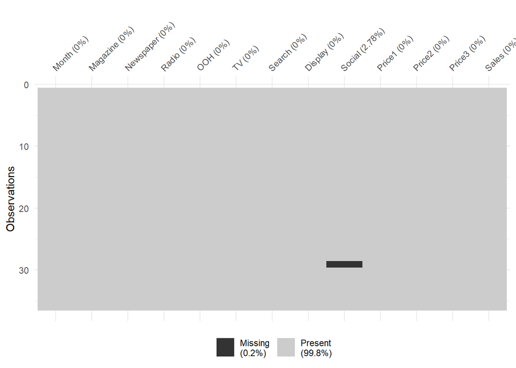

```r
vis_miss(rawdata, cluster = FALSE, sort_miss = FALSE, show_perc = TRUE,
         show_perc_col = TRUE, large_data_size = 9e+05,
         warn_large_data = TRUE)
```

##### 1.4 possible outliers

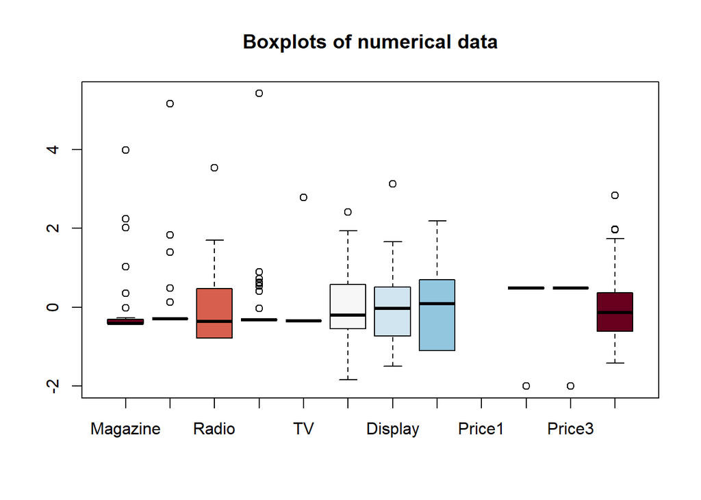

```r
data_num <- scale(rawdata[,-1],center =TRUE, scale = TRUE)
boxplot(x =data_num, use.cols = TRUE, notch = FALSE, varwidth = FALSE,  center=TRUE,
        horizontal = FALSE, col = brewer.pal(n = ncol(data_num), name = "RdBu"),range = 1.5, main = "Boxplots of numerical data")
```

##### 1.5 correlation

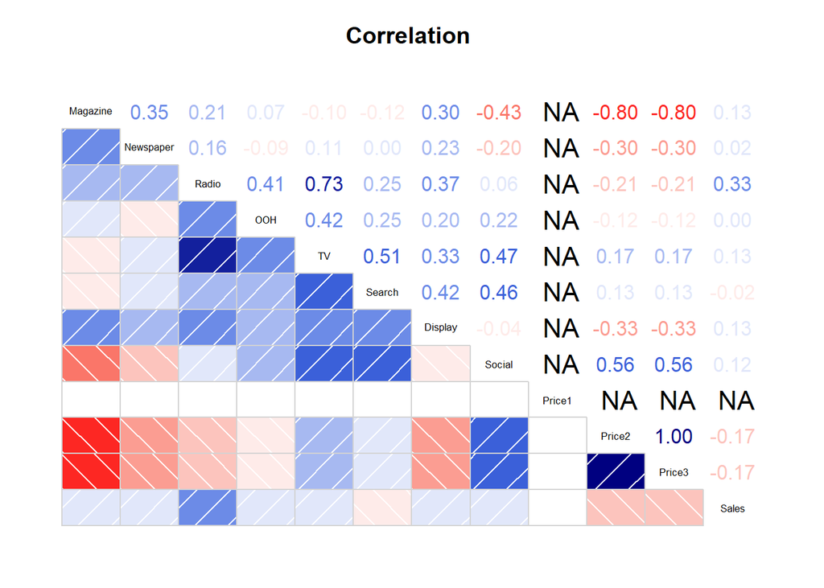

```r
corrgram(rawdata[,-1],
         text.panel = panel.txt,
         main = "Correlation ",
         lower.panel=panel.shade,
         upper.panel=panel.cor)
```

Some dimensions(Pirce2&Price3,Radio&TV) are highly correlated(absolute correlation coefficient of >0.7 among two predictors indicates the presence of multicollinearity

##### 1.6 visualziton

```r
library(xts)
```

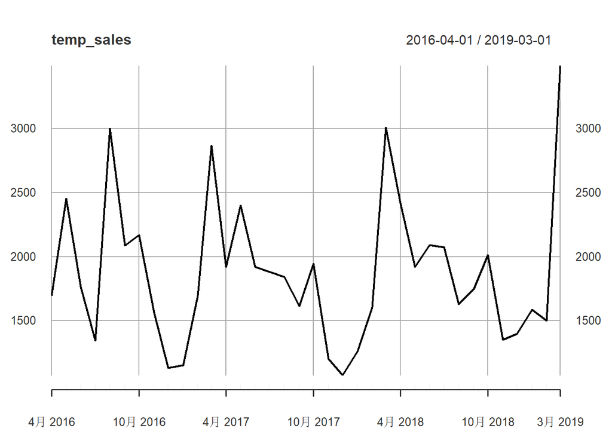

```r
temp_sales=xts(rawdata$Sales, rawdata$Month,frequency=12)
plot(temp_sales)
```

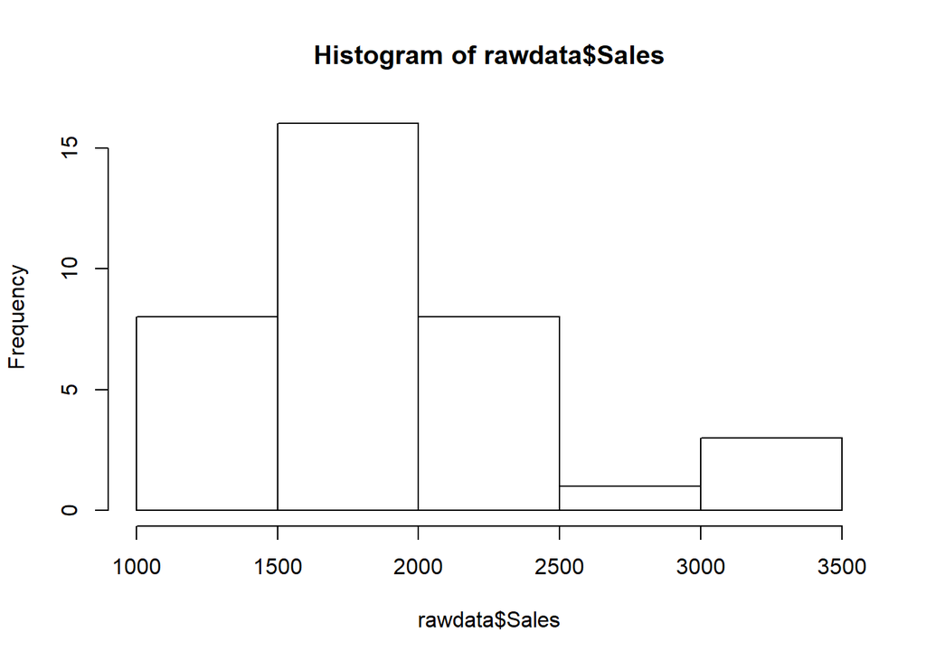

```r
hist(rawdata$Sales)
```

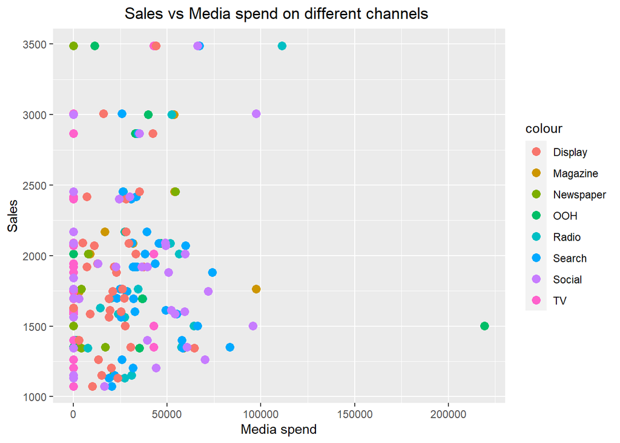

```r
ggplot(data = rawdata,aes(y=Sales))+
  geom_point(data = rawdata,aes(x=Magazine,colour='Magazine'),size=3) +
  geom_point(data = rawdata,aes(x=Newspaper,colour='Newspaper'),size=3)+
  geom_point(data = rawdata,aes(x=Radio,colour='Radio'),size=3) +
  geom_point(data = rawdata,aes(x=OOH,colour='OOH'),size=3)+
  geom_point(data = rawdata,aes(x=TV,colour='TV'),size=3)+
  geom_point(data = rawdata,aes(x=Search,colour='Search'),size=3) +
  geom_point(data = rawdata,aes(x=Display,colour='Display'),size=3) +
  geom_point(data = rawdata,aes(x=Social,colour='Social'),size=3) + xlab ("Media spend")+
  ggtitle ("Sales vs Media spend on different channels ") +
  theme(plot.title = element_text(hjust = 0.5))
```

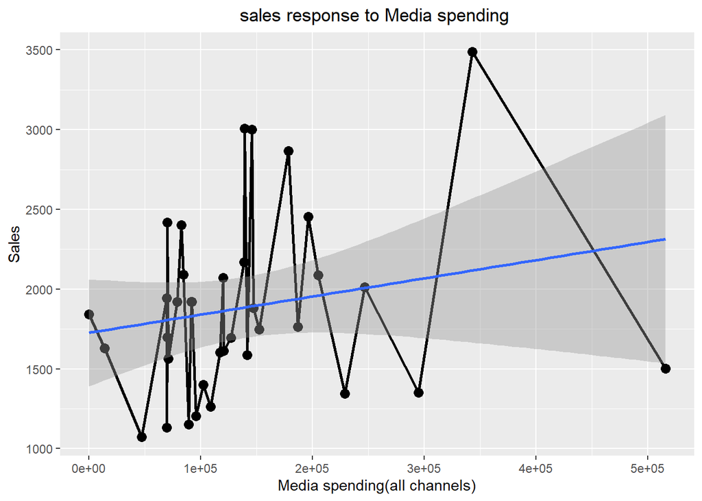

```r
X_ad=rawdata[,-c(1,10,11,12,13)]
sales=rawdata$Sales
total_spend=rowSums(X_ad,na.rm=TRUE)
temp=data.frame(sales,total_spend)
ggplot(data = temp,aes(y=sales,x=total_spend))+
  geom_point(aes(x=total_spend),size=3)+
  geom_line(aes(x=total_spend ),size=1)+ geom_smooth(method=lm)+
  xlab("Media spending(all channels)")+ylab("Sales")+
  ggtitle ("sales response to Media spending ") +
  theme(plot.title = element_text(hjust = 0.5))
```

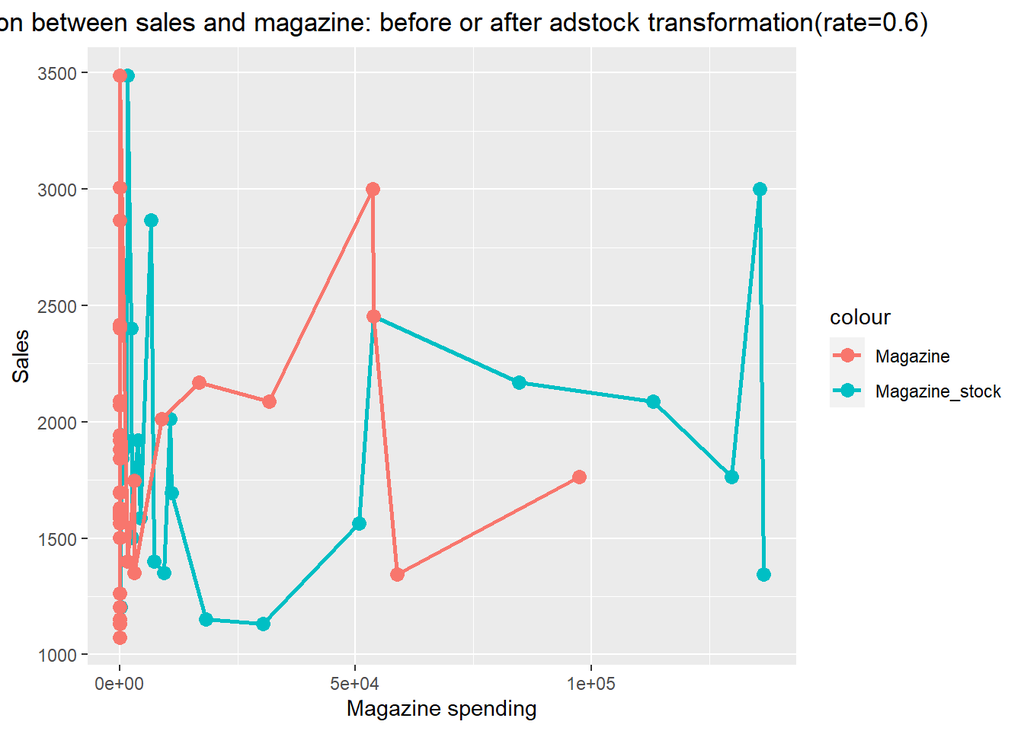

```r
Magazine_stock=stats::filter(x=rawdata$Magazine, filter=0.6, method="recursive")
ggplot(data = rawdata,aes(y=Sales))+
  geom_point(aes(x=Magazine_stock,colour='Magazine_stock'),size=3)+
  geom_line(aes(x=Magazine_stock, colour="Magazine_stock"),size=1)+
  geom_point(data =rawdata,aes(x=Magazine,colour='Magazine'),size=3)+
  geom_line(aes(x=Magazine, colour="Magazine"),size=1) +
  xlab("Magazine spending")+ylab("Sales")+
  ggtitle ("The relation between sales and magazine: before or after adstock transformation(rate=0.6)") +
  theme(plot.title = element_text(hjust = 0.6))
```

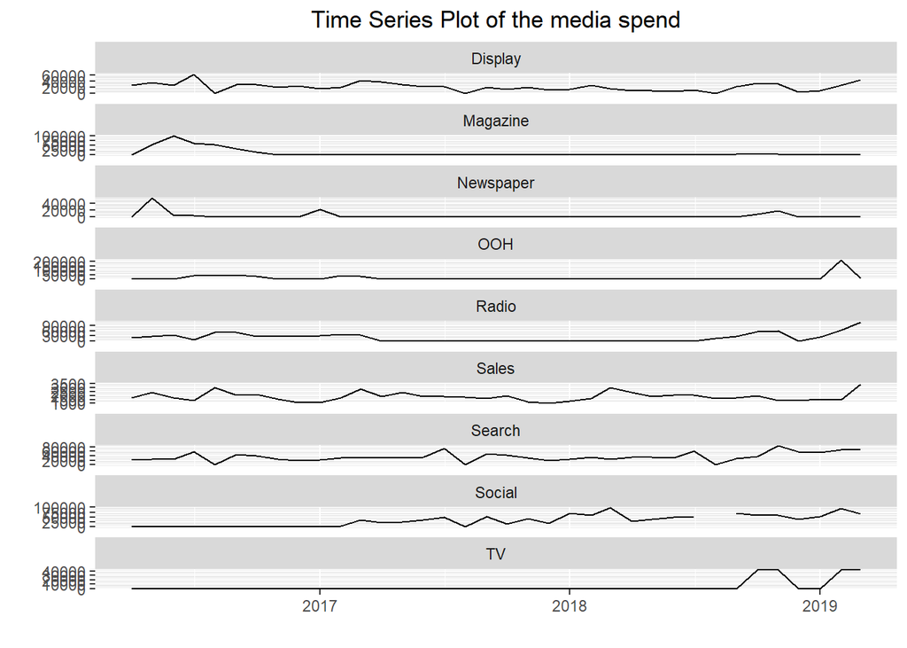

```r
ts_all=ts(rawdata[-1], start = c(2016, 4), freq = 12)
ts_ad=ts(rawdata[,-c(1,10,11,12)], start = c(2016, 4), freq = 12)
ts_price=ts(rawdata[,10:13], start = c(2016, 4), freq = 12)
ts_sales=ts(rawdata$Sales, start = c(2016, 4), freq = 12)

autoplot(ts_ad)+
  ggtitle("Time Series Plot of the media spend") +
  theme(plot.title = element_text(hjust = 0.5))
```

### 2 Data preparation

#### 2.1 change month’s data type

```r
#convert month to datetime
rawdata$Month=as.Date(rawdata$Month, origin="1970-01-01")
```

#### 2.2 impute social

```r
rawdata$Social <- impute(rawdata$Social,0)  #also always 0 on Augest
```

#### 2.3 check and transform sales

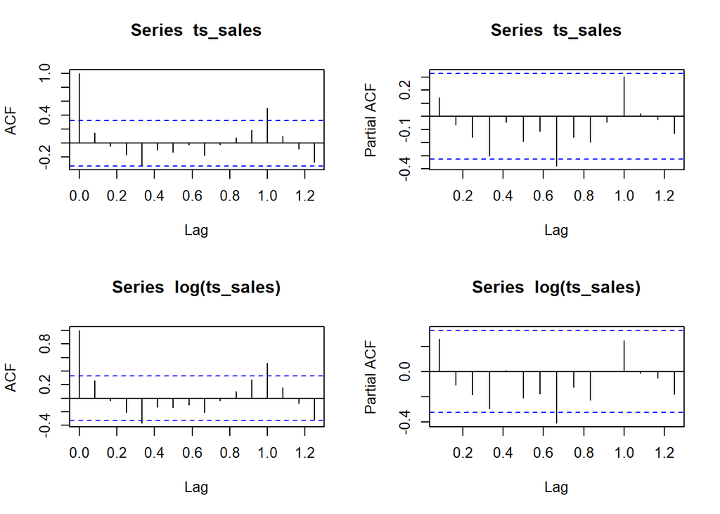

```r
par(mfrow=c(2,2))
acf(ts_sales)
pacf(ts_sales)


acf(log(ts_sales))
pacf(log(ts_sales))
```

```r
par(mfrow=c(1,1))
```

The autocorrelation exitsand and log transformation doesn’t work.Hence,I try to decompose sales  
to ensure its stationarity and independence

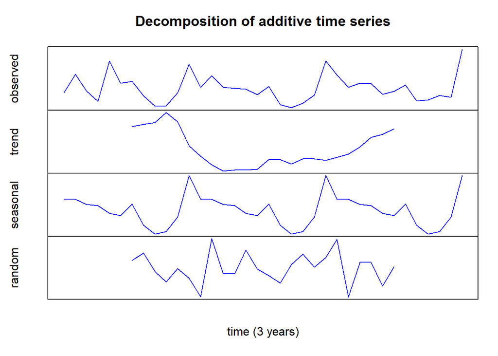

```r
ts_sales_components <- decompose(ts_sales) #Sort of a fourier transformation to decompose signal
plot(ts_sales_components, xlab="time (3 years)",cex=5, frame.plot=TRUE,col.axis="grey",col=c("blue"),axes=FALSE)
```

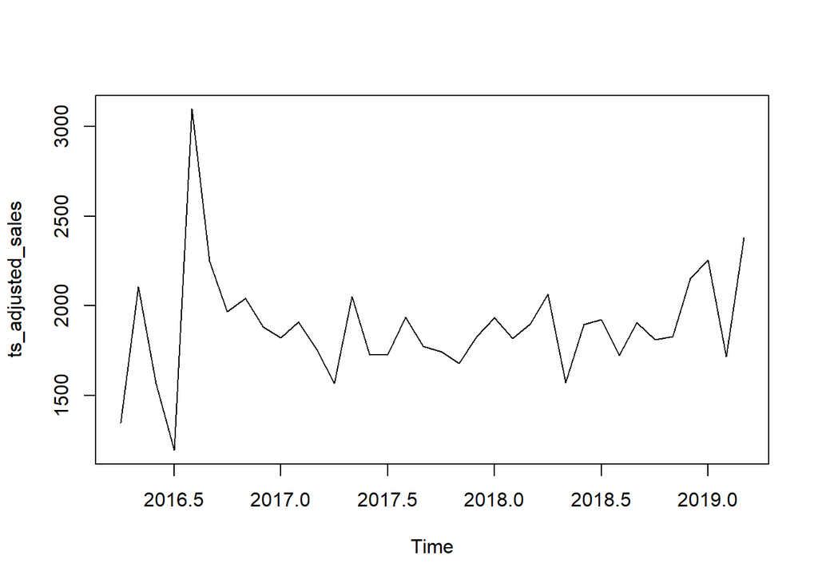

```r
ts_adjusted_sales <- ts_sales - ts_sales_components$seasonal
plot(ts_adjusted_sales)
```

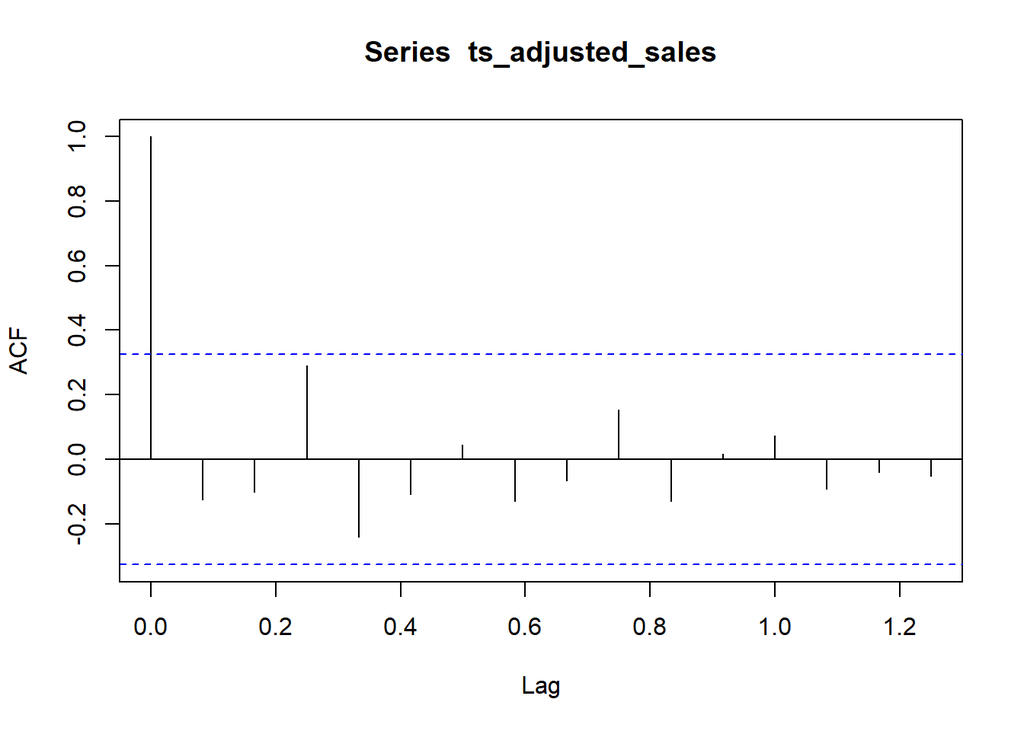

```r
acf(ts_adjusted_sales)
```

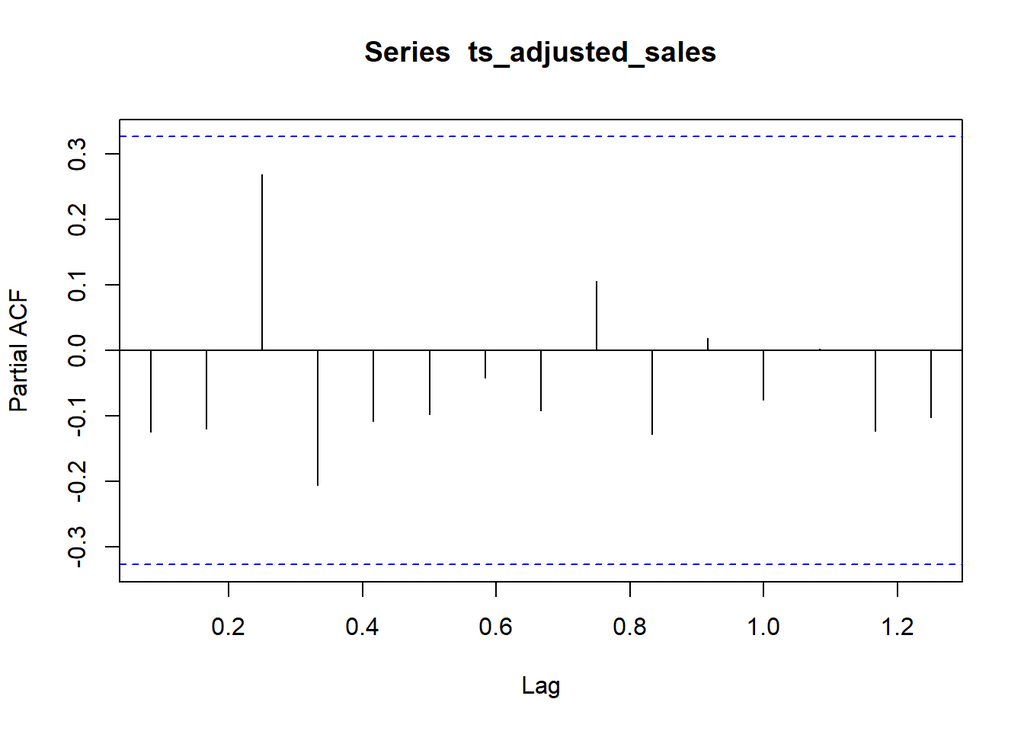

```r
pacf(ts_adjusted_sales)
```

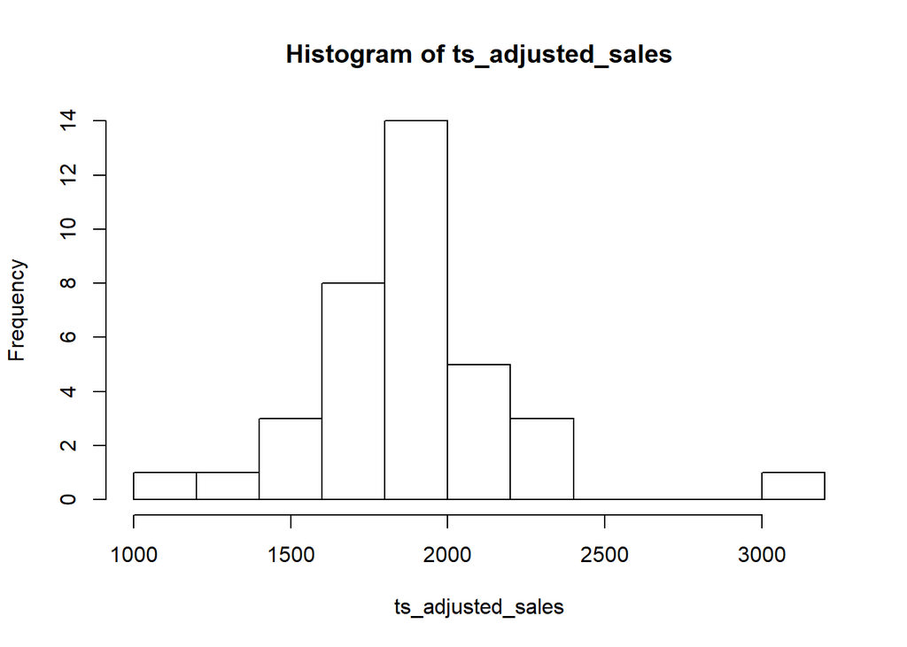

```r
hist(ts_adjusted_sales)
```

```r
#refrence https://rpubs.com/nihil0/mmm01
```

#### 2.4 train and test split

```r
set.seed(100)
ts_Split<- caret::createTimeSlices(y = 1:36, initialWindow =24, horizon =6, fixedWindow = T,skip = 0)
#horizon: The number of consecutive values in test set sample
# Nested Cross-Validation reference:
# https://lonepatient.top/2018/06/10/time-series-nested-cross-validation.html#2-%E4%BB%BB%E6%84%8F%E9%80%89%E6%8B%A9%E6%B5%8B%E8%AF%95%E9%9B%86
# https://scikit-learn.org/stable/modules/cross_validation.html
```

### 3 Model traing and tune parameters

```r
#seperated datasets
X_all=rawdata[,-c(1,13)]
X_ad=rawdata[,-c(1,10,11,12,13)]
X_price=rawdata[,10:12]
sales=rawdata$Sales
adjusted_sales=ts_adjusted_sales

adstock_Rates=seq(from=0, to=1, by=0.05)
Num_loop=length(ts_Split$train) # how many loops
vali_len=6                      #observation count for valiation
```

##### 3.1 Build Models and find the proper adstock Rates using Nested Cross-Validation

```r
#==================================
# AdstockTransform function
#==================================
#observation: the feature(s) to be transformed
#signal=0 sample linear Adstock transformed;    else: eg signal=1: using complicated method;   more transformation forms could be added.....
#rate : Adstock rate
#==================================
AdstockTransform <- function(observation,rate,signal){

  if(signal==0){
    for(i in names(observation))
    {
      observation[[i]]= as.numeric(stats::filter(x=observation[[i]], filter=rate, method="recursive"))
    }
  }
  else{
    for(i in names(observation))
    {
      observation[[i]]= as.numeric(stats::filter(x= 1/(1+exp(-2*observation[[i]])), filter=rate, method="recursive"))
    }
  }
 adstock_Df=data.frame(observation)

 return (adstock_Df)
}
```

```r
#==================================
# Get_bestRate function:
#==================================
# tf_signal：signal=0 sample linear Adstock transformed;    signal=1: using complicated method
# mediaChannel：ad predictors ,like TV, Radio....
# sales：Target variable
# vali_len：how many observations for validation
# Num_loop：how many times for cv,depends on the observation counts and  createTimeSlices()
# adstock_Rates：a list of Adstock rate
#==================================

Get_bestRate<-function(tf_signal, mediaChannel,sales,vali_len=6,Num_loop,adstock_Rates){

  #Container to save the cv results
  tuningResult<- data.frame(matrix(ncol = 3, nrow = 0))
  colnames(tuningResult) <- c("rate", "R2", "RMSE")

  best_Rate=0

  for(rate in adstock_Rates)
  {
    for(i in 1:Num_loop)
    {


      ColNames=names(mediaChannel)

      X=data.frame(mediaChannel[ts_Split$train[i][[1]],])
      y=sales[ts_Split$train[i][[1]]]
      nr=nrow(X)

      #adstockTransform
      adstock=AdstockTransform(X,rate,tf_signal)
      #filter first then split Train and Valiation as the first observation in Valiation set should be filtered


      # training and Valiation  split
      adstock_Train=data.frame(adstock[1:(nr-vali_len),])
      adstock_Valia=data.frame(adstock[(nr-vali_len+1):nr,])


      colnames(adstock_Train) <- ColNames
      colnames(adstock_Valia) <- ColNames


      y_Train=y[1:(nr-vali_len)]
      y_Valia=y[(nr-vali_len+1):nr]



      #Using a multiple regression model to fit the data
      modFit <- lm(y_Train~.,data=adstock_Train)

      #Valiation
      pred_y=predict(modFit,newdata=adstock_Valia)

      #meric
      R2=summary(modFit)$r.squared
      RMSE=rmse(y_Valia,pred_y)
      tuningResult=rbind(tuningResult,data.frame(rate, R2, RMSE) )

    }
  }

  cv_result=tuningResult%>% group_by(rate)%>%
    summarise(
      R2_avg= mean(R2),
      RMSE_avg = mean(RMSE)
    )

  cv_result=data.frame(cv_result)
  best_Rate=cv_result[which.max(cv_result$R2_avg),1]

  out <- list(cv_result=cv_result, best_Rate=best_Rate)
  return(out)
}
```

##### 3.2 supposing all channels have the same adstock_Rate

```r
#assuming:
# all the channels have the same adstock_Rates
# Simple Decay-Effect Model


 result_adjusted=Get_bestRate(0,X_ad,adjusted_sales,vali_len,Num_loop,adstock_Rates)
 result_adjusted$cv_result
```

```
##    rate    R2_avg  RMSE_avg
## 1  0.00 0.7397218  210.0536
## 2  0.05 0.7295080  218.0163
## 3  0.10 0.7183613  227.3911
## 4  0.15 0.7064551  238.4636
## 5  0.20 0.6939492  251.5668
## 6  0.25 0.6809936  267.0790
## 7  0.30 0.6677357  285.4237
## 8  0.35 0.6543343  307.0723
## 9  0.40 0.6409787  332.5572
## 10 0.45 0.6279148  362.5103
## 11 0.50 0.6154701  397.7544
## 12 0.55 0.6040776  439.4796
## 13 0.60 0.5942932  489.4918
## 14 0.65 0.5867775  550.3659
## 15 0.70 0.5821259  625.0565
## 16 0.75 0.5803767  715.4369
## 17 0.80 0.5803927  820.2666
## 18 0.85 0.5800293  935.0964
## 19 0.90 0.5774823 1056.2928
## 20 0.95 0.5723806 1193.0932
## 21 1.00 0.5481132 1307.3205
```

```r
 result_adjusted$best_Rate    #0.00  0.7397218
```

```
## [1] 0
```

```r
 #modeling
 ad_adstock_adjusted=AdstockTransform(X_ad,result_adjusted$best_Rate,0)
 modFit.1 <- lm(adjusted_sales~.,data=ad_adstock_adjusted)
 summary(modFit.1)
```

```
##
## Call:
## lm(formula = adjusted_sales ~ ., data = ad_adstock_adjusted)
##
## Residuals:
##     Min      1Q  Median      3Q     Max
## -479.42  -50.92   17.05  106.85  588.93
##
## Coefficients:
##               Estimate Std. Error t value Pr(>|t|)
## (Intercept)  1.854e+03  1.159e+02  16.000 2.67e-15 ***
## Magazine     8.870e-04  2.309e-03   0.384 0.703896
## Newspaper    3.099e-03  4.583e-03   0.676 0.504662
## Radio        1.216e-02  2.737e-03   4.445 0.000135 ***
## OOH         -7.669e-04  1.231e-03  -0.623 0.538430
## TV          -1.329e-02  5.909e-03  -2.250 0.032820 *
## Search       1.337e-03  2.788e-03   0.479 0.635500
## Display     -1.369e-02  3.626e-03  -3.776 0.000798 ***
## Social       2.407e-03  1.924e-03   1.251 0.221639
## ---
## Signif. codes:  0 '***' 0.001 '**' 0.01 '*' 0.05 '.' 0.1 ' ' 1
##
## Residual standard error: 239.6 on 27 degrees of freedom
## Multiple R-squared:  0.5551, Adjusted R-squared:  0.4233
## F-statistic: 4.212 on 8 and 27 DF,  p-value: 0.002231
```

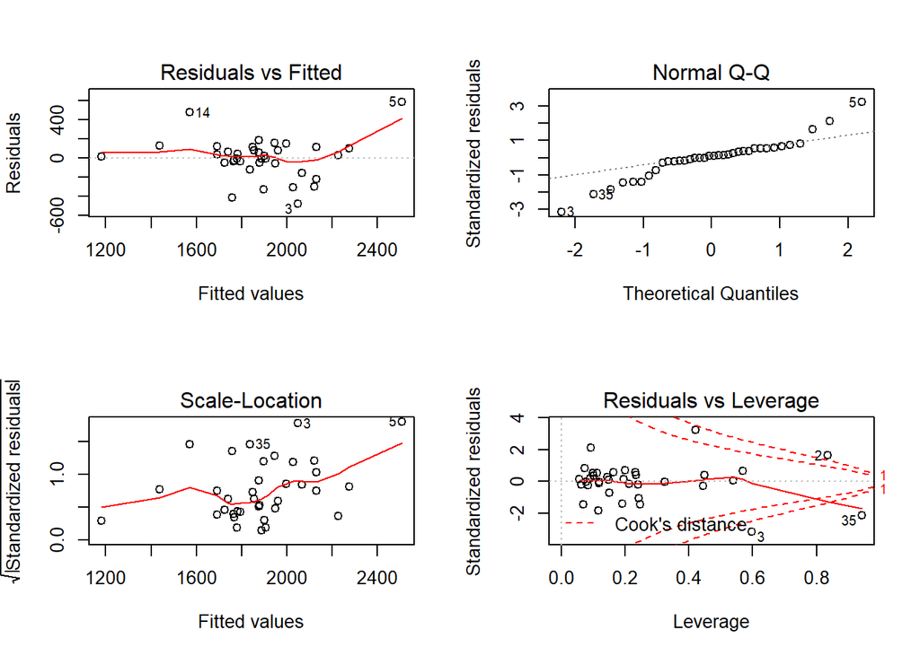

```r
 par(mfrow=c(2,2))
 plot(modFit.1)
```

```r
 par(mfrow=c(1,1))
```

```r
#assuming:
# all the channels have the same adstock_Rates
# complex Decay-Effect Model

 result_adjusted=Get_bestRate(1,X_ad,adjusted_sales,vali_len,Num_loop,adstock_Rates)
 result_adjusted$cv_result
```

```
##    rate    R2_avg RMSE_avg
## 1  0.00 0.6495978 189.4877
## 2  0.05 0.7141093 188.3371
## 3  0.10 0.7163804 189.3220
## 4  0.15 0.7178615 190.4516
## 5  0.20 0.7186005 191.7249
## 6  0.25 0.7186469 193.1446
## 7  0.30 0.7180587 194.7178
## 8  0.35 0.7169061 196.4541
## 9  0.40 0.7152736 198.3606
## 10 0.45 0.7132586 200.5460
## 11 0.50 0.7109672 203.6344
## 12 0.55 0.7085082 210.0697
## 13 0.60 0.7059852 212.1531
## 14 0.65 0.7034899 216.0016
## 15 0.70 0.7010953 220.8201
## 16 0.75 0.6988519 226.5891
## 17 0.80 0.6967868 233.4216
## 18 0.85 0.6949057 241.4994
## 19 0.90 0.6931968 251.0759
## 20 0.95 0.6916365 262.5008
## 21 1.00 0.6901954 276.2585
```

```r
 result_adjusted$best_Rate    #0.25  0.7186469
```

```
## [1] 0.25
```

```r
 #modeling
 ad_adstock_adjusted=AdstockTransform(X_ad,result_adjusted$best_Rate,1)
 modFit.2 <- lm(adjusted_sales~.,data=ad_adstock_adjusted)
 summary(modFit.2)
```

```
##
## Call:
## lm(formula = adjusted_sales ~ ., data = ad_adstock_adjusted)
##
## Residuals:
##     Min      1Q  Median      3Q     Max
## -582.68 -158.01   -7.78  138.10  714.55
##
## Coefficients: (1 not defined because of singularities)
##             Estimate Std. Error t value Pr(>|t|)
## (Intercept)  2055.70     487.87   4.214 0.000236 ***
## Magazine      457.22     264.40   1.729 0.094774 .
## Newspaper    -539.70     359.13  -1.503 0.144087
## Radio         162.37     277.77   0.585 0.563534
## OOH           204.18     248.20   0.823 0.417669
## TV             58.66     396.84   0.148 0.883543
## Search       -624.92     425.06  -1.470 0.152661
## Display           NA         NA      NA       NA
## Social        251.13     292.25   0.859 0.397477
## ---
## Signif. codes:  0 '***' 0.001 '**' 0.01 '*' 0.05 '.' 0.1 ' ' 1
##
## Residual standard error: 291.4 on 28 degrees of freedom
## Multiple R-squared:  0.318,  Adjusted R-squared:  0.1475
## F-statistic: 1.865 on 7 and 28 DF,  p-value: 0.1139
```

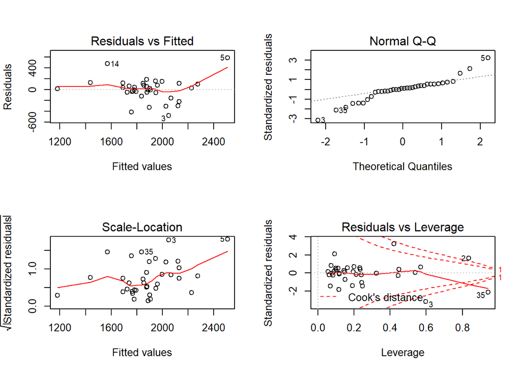

```r
 par(mfrow=c(2,2))
 plot(modFit.1)
```

```r
 par(mfrow=c(1,1))
```

##### 3.3 supposing each advertising variable has it’s own adstock_Rate

```r
#assuming:
# each advertising variable has it’s own adstock_Rate
# complex Decay-Effect Mode


 # Magazine
 # adjusted_sales
 Magazine=data.frame(X_ad$Magazine)
 result_Magazine=Get_bestRate(1,Magazine,adjusted_sales,vali_len,Num_loop,adstock_Rates)
 # result_Magazine$cv_result
 # result_Magazine$best_Rate   #0.75


 # Newspaper
 # adjusted_sales
 Newspaper=data.frame(X_ad$Newspaper)
 result_Newspaper=Get_bestRate(1,Newspaper,adjusted_sales,vali_len,Num_loop,adstock_Rates)
 # result_Newspaper$cv_result
 # result_Newspaper$best_Rate   #0.75



 # Radio
 # adjusted_sales
 Radio=data.frame(X_ad$Radio)
 result_Radio=Get_bestRate(1,Radio,adjusted_sales,vali_len,Num_loop,adstock_Rates)
 # result_Radio$cv_result
 # result_Radio$best_Rate   # 0.90


 # OOH
 # adjusted_sales
 OOH=data.frame(X_ad$OOH)
 result_OOH=Get_bestRate(1,OOH,adjusted_sales,vali_len,Num_loop,adstock_Rates)
 # result_OOH$cv_result
 # result_OOH$best_Rate   #  0.80


 # TV
 # adjusted_sales
 TV=data.frame(X_ad$TV)
 result_TV=Get_bestRate(1,TV,adjusted_sales,vali_len,Num_loop,adstock_Rates)
 # result_TV$cv_result
 # result_TV$best_Rate   # 0.40


 # Search
 # adjusted_sales
 Search=data.frame(X_ad$Search)
 result_Search=Get_bestRate(1,Search,adjusted_sales,vali_len,Num_loop,adstock_Rates)
 # result_Search$cv_result
 # result_Search$best_Rate   # 0.2



 # Display
 # adjusted_sales
 Display=data.frame(X_ad$Display)
 result_Display=Get_bestRate(1,Display,adjusted_sales,vali_len,Num_loop,adstock_Rates)
 # result_Display$cv_result
 # result_Display$best_Rate   # 0.2


 # Social
 # adjusted_sales
 Social=data.frame(X_ad$Social)
 result_Social=Get_bestRate(1,Social,adjusted_sales,vali_len,Num_loop,adstock_Rates)
 # result_Social$cv_result
 # result_Social$best_Rate   # 0.4

 #"Magazine"  "Newspaper" "Radio"     "OOH"       "TV"        "Search"    "Display"   "Social"
Magazine.adstock=AdstockTransform(Magazine,result_Magazine$best_Rate,1)
Newspaper.adstock=AdstockTransform(Newspaper,result_Newspaper$best_Rate,1)
Radio.adstock=AdstockTransform(Radio,result_Radio$best_Rate,1)
OOH.adstock=AdstockTransform(OOH,result_OOH$best_Rate,1)
TV.adstock=AdstockTransform(TV,result_TV$best_Rate,1)
Search.adstock=AdstockTransform(Search,result_Search$best_Rate,1)
Display.adstock=AdstockTransform(Display,result_Display$best_Rate,1)
Social.adstock=AdstockTransform(Social,result_Social$best_Rate,1)

#modeling
media_ad=c(Magazine.adstock,Newspaper.adstock,Radio.adstock,OOH.adstock,TV.adstock,Search.adstock,Display.adstock,Social.adstock)
modFit.3 <-lm(adjusted_sales~.,data=media_ad)
summary(modFit.3)
```

```
##
## Call:
## lm(formula = adjusted_sales ~ ., data = media_ad)
##
## Residuals:
##    Min     1Q Median     3Q    Max
## -533.2 -170.9  -20.7  100.4  646.7
##
## Coefficients: (1 not defined because of singularities)
##                Estimate Std. Error t value Pr(>|t|)
## (Intercept)     2270.71     451.54   5.029 2.56e-05 ***
## X_ad.Magazine    495.46     187.08   2.648   0.0131 *
## X_ad.Newspaper  -337.17     267.46  -1.261   0.2178
## X_ad.Radio       -95.12      93.11  -1.022   0.3158
## X_ad.OOH         114.04     149.21   0.764   0.4511
## X_ad.TV           95.49     343.27   0.278   0.7829
## X_ad.Search     -971.32     364.40  -2.666   0.0126 *
## X_ad.Display         NA         NA      NA       NA
## X_ad.Social      360.48     231.24   1.559   0.1303
## ---
## Signif. codes:  0 '***' 0.001 '**' 0.01 '*' 0.05 '.' 0.1 ' ' 1
##
## Residual standard error: 276.1 on 28 degrees of freedom
## Multiple R-squared:  0.3877, Adjusted R-squared:  0.2346
## F-statistic: 2.532 on 7 and 28 DF,  p-value: 0.03757
```

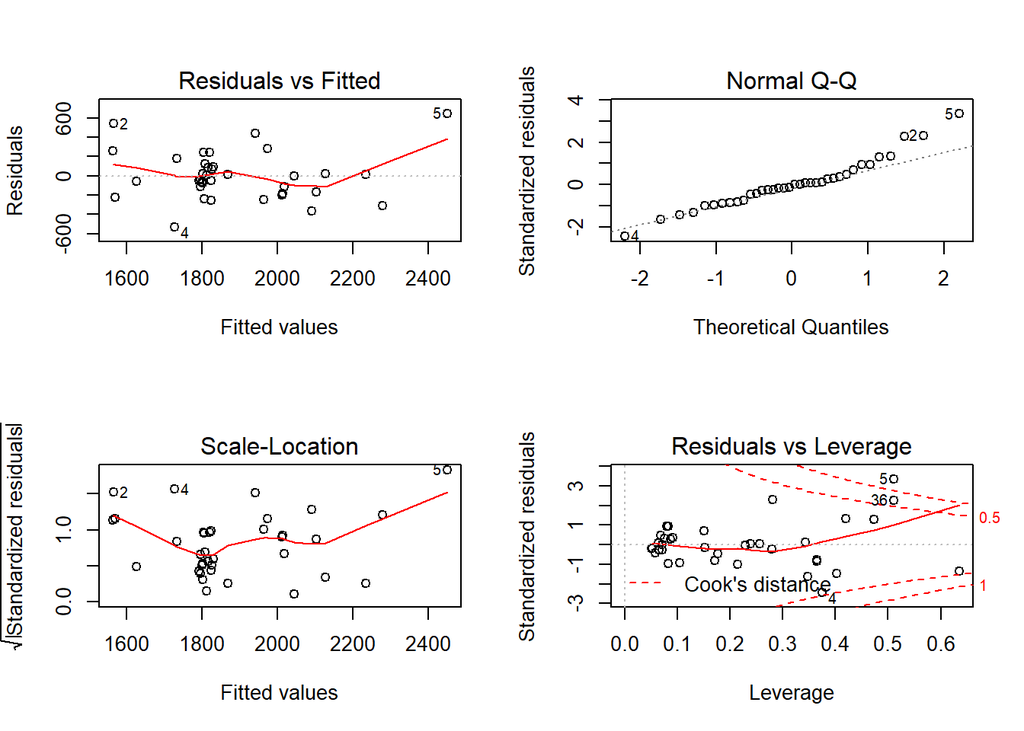

```r
par(mfrow=c(2,2))
plot(modFit.3)
```

```r
par(mfrow=c(1,1))
```

```r
ChannelName=names(X_ad)
AdstockRate=c(result_Magazine$best_Rate,
              result_Newspaper$best_Rate,
              result_Radio$best_Rate,
              result_OOH$best_Rate,
              result_TV$best_Rate,
              result_Search$best_Rate ,
              result_Display$best_Rate,
              result_Social$best_Rate)
cbind(ChannelName,AdstockRate)
```

```
##      ChannelName AdstockRate
## [1,] "Magazine"  "0.75"
## [2,] "Newspaper" "0.75"
## [3,] "Radio"     "0.9"
## [4,] "OOH"       "0.8"
## [5,] "TV"        "0.4"
## [6,] "Search"    "0.2"
## [7,] "Display"   "0.2"
## [8,] "Social"    "0.4"
```

```r
#assuming:
# each advertising variable has it’s own adstock_Rate
# simple  Decay-Effect Mode

# Magazine
# adjusted_sales
Magazine=data.frame(X_ad$Magazine)
result_Magazine=Get_bestRate(0,Magazine,adjusted_sales,vali_len,Num_loop,adstock_Rates)
# result_Magazine$cv_result
# result_Magazine$best_Rate    #0.6

# Newspaper
# adjusted_sales
Newspaper=data.frame(X_ad$Newspaper)
result_Newspaper=Get_bestRate(0,Newspaper,adjusted_sales,vali_len,Num_loop,adstock_Rates)
# result_Newspaper$cv_result
# result_Newspaper$best_Rate   #1

# Radio
# adjusted_sales
Radio=data.frame(X_ad$Radio)
result_Radio=Get_bestRate(0,Radio,adjusted_sales,vali_len,Num_loop,adstock_Rates)
# result_Radio$cv_result
# result_Radio$best_Rate   #0

# OOH
# adjusted_sales
OOH=data.frame(X_ad$OOH)
result_OOH=Get_bestRate(0,OOH,adjusted_sales,vali_len,Num_loop,adstock_Rates)
# result_OOH$cv_result
# result_OOH$best_Rate    #1

# TV
# adjusted_sales
TV=data.frame(X_ad$TV)
result_TV=Get_bestRate(0,TV,adjusted_sales,vali_len,Num_loop,adstock_Rates)
# result_TV$cv_result
# result_TV$best_Rate   #0


# Search
# adjusted_sales
Search=data.frame(X_ad$Search)
result_Search=Get_bestRate(0,Search,adjusted_sales,vali_len,Num_loop,adstock_Rates)
# result_Search$cv_result
# result_Search$best_Rate    #0.6

# Display
# adjusted_sales
Display=data.frame(X_ad$Display)
result_Display=Get_bestRate(0,Display,adjusted_sales,vali_len,Num_loop,adstock_Rates)
# result_Display$cv_result
# result_Display$best_Rate  #0

# Social
# adjusted_sales
Social=data.frame(X_ad$Social)
result_Social=Get_bestRate(0,Social,adjusted_sales,vali_len,Num_loop,adstock_Rates)
# result_Social$cv_result
# result_Social$best_Rate   #0.35

#"Magazine"  "Newspaper" "Radio"     "OOH"       "TV"        "Search"    "Display"   "Social"
Magazine.adstock=AdstockTransform(Magazine,result_Magazine$best_Rate,0)
Newspaper.adstock=AdstockTransform(Newspaper,result_Newspaper$best_Rate,0)
Radio.adstock=AdstockTransform(Radio,result_Radio$best_Rate,0)
OOH.adstock=AdstockTransform(OOH,result_OOH$best_Rate,0)
TV.adstock=AdstockTransform(TV,result_TV$best_Rate,0)
Search.adstock=AdstockTransform(Search,result_Search$best_Rate,0)
Display.adstock=AdstockTransform(Display,result_Display$best_Rate,0)
Social.adstock=AdstockTransform(Social,result_Social$best_Rate,0)

#modeling
media_ad=c(Magazine.adstock,Newspaper.adstock,Radio.adstock,OOH.adstock,TV.adstock,Search.adstock,Display.adstock,Social.adstock)
modFit.4 <-lm(adjusted_sales~.,data=media_ad)
summary(modFit.4)
```

```
##
## Call:
## lm(formula = adjusted_sales ~ ., data = media_ad)
##
## Residuals:
##     Min      1Q  Median      3Q     Max
## -525.93  -59.04   27.34   80.98  470.71
##
## Coefficients:
##                  Estimate Std. Error t value Pr(>|t|)
## (Intercept)     1.546e+03  2.271e+02   6.806 2.61e-07 ***
## X_ad.Magazine   2.047e-03  1.565e-03   1.308 0.201913
## X_ad.Newspaper  3.521e-03  3.744e-03   0.941 0.355265
## X_ad.Radio      1.099e-02  2.924e-03   3.759 0.000835 ***
## X_ad.OOH       -5.569e-05  9.891e-04  -0.056 0.955511
## X_ad.TV        -1.403e-02  6.009e-03  -2.334 0.027256 *
## X_ad.Search     1.979e-04  2.363e-03   0.084 0.933868
## X_ad.Display   -1.192e-02  3.298e-03  -3.614 0.001216 **
## X_ad.Social     2.035e-03  1.742e-03   1.168 0.252954
## ---
## Signif. codes:  0 '***' 0.001 '**' 0.01 '*' 0.05 '.' 0.1 ' ' 1
##
## Residual standard error: 226.2 on 27 degrees of freedom
## Multiple R-squared:  0.6036, Adjusted R-squared:  0.4862
## F-statistic:  5.14 on 8 and 27 DF,  p-value: 0.0005854
```

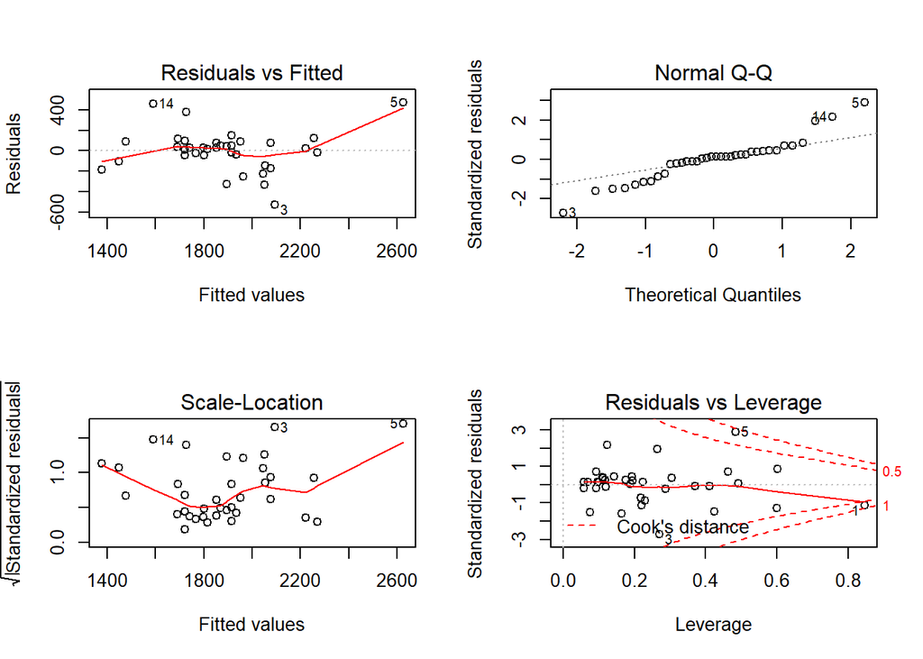

```r
par(mfrow=c(2,2))
plot(modFit.4)
```

```r
par(mfrow=c(1,1))
```

modFit.4 has the larger R2 among the models ,so 60.36% of the variability of the response data can bee explained by the model.

```r
##Checking for multicolinearity within the independent variables using VIF
vif(modFit.4)
```

```
##  X_ad.Magazine X_ad.Newspaper     X_ad.Radio       X_ad.OOH        X_ad.TV
##       2.985780       3.814674       3.858468       5.836541       4.610307
##    X_ad.Search   X_ad.Display    X_ad.Social
##       3.276359       1.439316       3.236050
```

Most scores are less than 5 except OOH,but it still leee than 10, so we could assume there is no multicolliniarity between the independent variables.

```r
##----compare
modFit.0 <-lm(sales~.,data=X_ad)
modFit.0_1 <-lm(adjusted_sales~.,data=X_ad)
R2_before_0=summary(modFit.0)$r.squared
R2_before=summary(modFit.0_1)$r.squared
R2_after=summary(modFit.4)$r.square
R2_before_0
```

```
## [1] 0.2586828
```

```r
R2_before
```

```
## [1] 0.5551455
```

```r
R2_after
```

```
## [1] 0.6036372
```

Model performence increases when adstock is involved.

#### 3.4 Model reuslts analysis

##### 3.4.1 Adstock rate

```r
#Adstock rate is a measurement of the advertising decay effect.
ChannelName=names(X_ad)
AdstockRate=c(result_Magazine$best_Rate,
        result_Newspaper$best_Rate,
        result_Radio$best_Rate,
        result_OOH$best_Rate,
        result_TV$best_Rate,
        result_Search$best_Rate ,
        result_Display$best_Rate,
        result_Social$best_Rate)
cbind(ChannelName,AdstockRate)
```

```
##      ChannelName AdstockRate
## [1,] "Magazine"  "0.6"
## [2,] "Newspaper" "1"
## [3,] "Radio"     "0"
## [4,] "OOH"       "1"
## [5,] "TV"        "0"
## [6,] "Search"    "0.6"
## [7,] "Display"   "0"
## [8,] "Social"    "0.35"
```

##### 3.4.2 Decay effect

Adstock Affect: the prolonged or lagged effect of advertising on consumer purchase behaviour  
There are two dimensions to advertising adstock:  
* Decay effect:the impact of past advertisement on present sales;  
* saturation or diminishing returns effect.

According to the Adstock Rates we have got in this case, decay effect exits on Magazine,Newspaper,OOH,Search and Social channels.

Take the magezine as an example,

```r
Magazine.adstock=AdstockTransform(Magazine,0.6,0)
Magazine.adstock=data.frame(Magazine.adstock[[1]])
colnames(Magazine.adstock)="Magazine.adstock"
Magazine.original=rawdata$Magazine
Sales=rawdata$Sales
#adjusted_sales
compare_df=data.frame(Sales,adjusted_sales,Magazine.original=Magazine.original,Magazine.adstock=Magazine.adstock)
```

```r
mg_lm_1=lm(adjusted_sales~Magazine.original,data=compare_df)
mg_lm_2=lm(adjusted_sales~Magazine.adstock,data=compare_df)

intercept1=coefficients(summary(mg_lm_1))[1]
slope1=coefficients(summary(mg_lm_1))[2]
R2_1=summary(mg_lm_1)$r.squared

intercept2=coefficients(summary(mg_lm_2))[1]
slope2=coefficients(summary(mg_lm_2))[2]
R2_2=summary(mg_lm_2)$r.squared
```

```r
Before_Adstock=c(intercept1,slope1,R2_1)
Aftter_Adstock=c(intercept2,slope2,R2_2)
result_comp=rbind(Before_Adstock,Aftter_Adstock)
colnames(result_comp)<-c("Intercept","Slope","R2")
result_comp
```

```
##                Intercept       Slope          R2
## Before_Adstock  1874.405 0.001059659 0.005510813
## Aftter_Adstock  1848.794 0.001549930 0.043005985
```

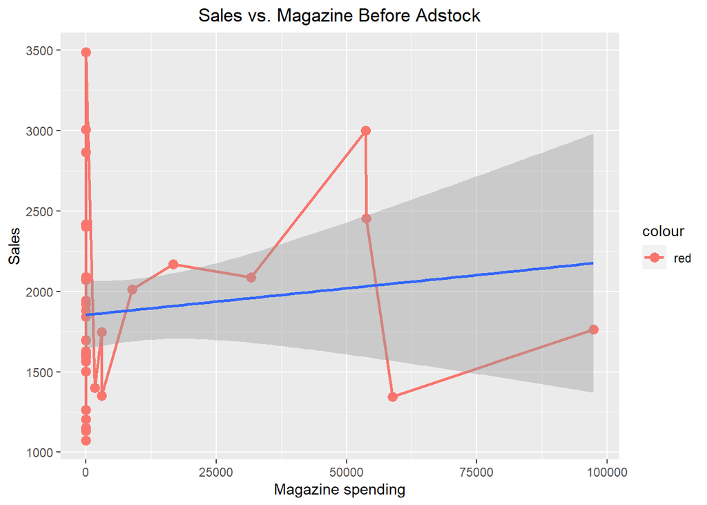

```r
ggplot(data =compare_df,aes(y=Sales,x=Magazine.original))+
  geom_point(data =compare_df,aes(x=Magazine.original,colour='red'),size=3)+
  geom_line(aes(x=Magazine.original, colour="red"),size=1) +
  xlab("Magazine spending")+ylab("Sales")+
  ggtitle ("Sales vs. Magazine Before Adstock") +geom_smooth(method=lm)+
  theme(plot.title = element_text(hjust = 0.5))
```

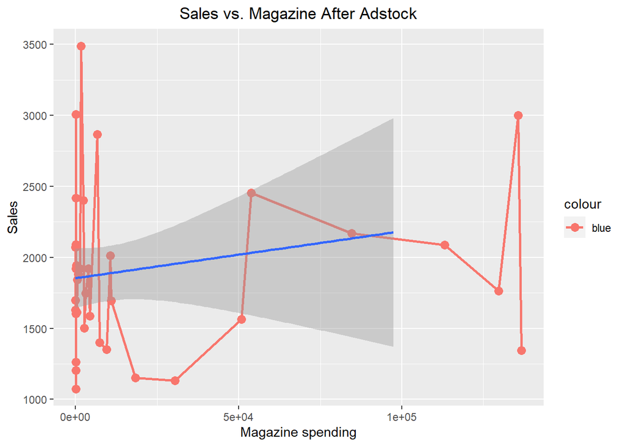

```r
ggplot(data = compare_df,aes(y=Sales,x=Magazine.original))+
  geom_point(data =compare_df,aes(x=Magazine.adstock,colour='blue'),size=3)+
  geom_line(aes(x=Magazine.adstock, colour="blue"),size=1) +
  xlab("Magazine spending")+ylab("Sales")+
  ggtitle ("Sales vs. Magazine After Adstock") +geom_smooth(method=lm)+
  theme(plot.title = element_text(hjust = 0.5))
```

```r
#How much to spend on marketing activities to increase sales by some percent (15%)?
summary(modFit.4)
```

```
##
## Call:
## lm(formula = adjusted_sales ~ ., data = media_ad)
##
## Residuals:
##     Min      1Q  Median      3Q     Max
## -525.93  -59.04   27.34   80.98  470.71
##
## Coefficients:
##                  Estimate Std. Error t value Pr(>|t|)
## (Intercept)     1.546e+03  2.271e+02   6.806 2.61e-07 ***
## X_ad.Magazine   2.047e-03  1.565e-03   1.308 0.201913
## X_ad.Newspaper  3.521e-03  3.744e-03   0.941 0.355265
## X_ad.Radio      1.099e-02  2.924e-03   3.759 0.000835 ***
## X_ad.OOH       -5.569e-05  9.891e-04  -0.056 0.955511
## X_ad.TV        -1.403e-02  6.009e-03  -2.334 0.027256 *
## X_ad.Search     1.979e-04  2.363e-03   0.084 0.933868
## X_ad.Display   -1.192e-02  3.298e-03  -3.614 0.001216 **
## X_ad.Social     2.035e-03  1.742e-03   1.168 0.252954
## ---
## Signif. codes:  0 '***' 0.001 '**' 0.01 '*' 0.05 '.' 0.1 ' ' 1
##
## Residual standard error: 226.2 on 27 degrees of freedom
## Multiple R-squared:  0.6036, Adjusted R-squared:  0.4862
## F-statistic:  5.14 on 8 and 27 DF,  p-value: 0.0005854
```

- The base sales(adjusted) is 1546;
- For one unit increase in Radio spending, there will be a 0.011 unit increase in adjusted_sales;
- ??? Why negtive slopes?

### 4 Model testing

```r
#all the ad_transformed media spend
media_ad=data.frame(media_ad)  #got when buiding modFit.4
adjusted_sales
```

```
##           Jan      Feb      Mar      Apr      May      Jun      Jul      Aug
## 2016                            1345.125 2103.917 1568.083 1193.188 3096.646
## 2017 1821.208 1909.271 1757.042 1568.125 2049.917 1726.083 1729.188 1936.646
## 2018 1932.208 1817.271 1898.042 2066.125 1568.917 1895.083 1921.188 1723.646
## 2019 2254.208 1714.271 2379.042
##           Sep      Oct      Nov      Dec
## 2016 2247.542 1967.688 2040.063 1883.229
## 2017 1772.542 1742.688 1678.063 1826.229
## 2018 1905.542 1809.688 1828.063 2151.229
## 2019
```

```r
#ts_Split$train
#ts_Split$test

ColNames=names(media_ad)

testing_result<- data.frame(matrix(ncol = 3, nrow = 0))
colnames(testing_result) <- c( "R2", "RMSE","MAPE")

for(i in 1:Num_loop)
{
  #get the trainnin and testing data
  adstock_Train=data.frame(media_ad[ts_Split$train[i][[1]],])
  y_Train=adjusted_sales[ts_Split$train[i][[1]]]


  adstock_Test=data.frame(media_ad[ts_Split$test[i][[1]],])
  y_test=adjusted_sales[ts_Split$test[i][[1]]]

  colnames(adstock_Train) <- ColNames
  colnames(adstock_Test) <- ColNames

  modFit <-lm(y_Train~.,data= adstock_Train)


  #test
  y_pred=predict(modFit,newdata=adstock_Test)

  #meric
  R2=summary(modFit)$r.squared
  RMSE=rmse(y_test,y_pred) # rmse(actual, predicted)
  MAPE=MAPE(y_pred,y_test)# MAPE(y_pred, y_true)
  testing_result=rbind(testing_result,data.frame(R2, RMSE,MAPE) )

}

testing_result%>%
  summarise(
    R2_avg= mean(R2),
    RMSE_avg = mean(RMSE),
    MAPE_avg = mean(MAPE)
)
```

```
##      R2_avg RMSE_avg  MAPE_avg
## 1 0.6426396 272.7579 0.1201196
```

Model having MAPE nearly 10% is considered as not bad model.

### 5 Contribution Charts

```r
# calculating the relative importance of different marketing variables and structural components

relative_importance=calc.relimp(modFit.4, type = c("car"), rela = TRUE)
#used 'car' as cost function; rela=TRUE give % that a variable contributed to the adjusted R2
relative_importance
```

```
## Response variable: adjusted_sales
## Total response variance: 99592.1
## Analysis based on 36 observations
##
## 8 Regressors:
## X_ad.Magazine X_ad.Newspaper X_ad.Radio X_ad.OOH X_ad.TV X_ad.Search X_ad.Display X_ad.Social
## Proportion of variance explained by model: 60.36%
## Metrics are normalized to sum to 100% (rela=TRUE).
##
## Relative importance metrics:
##
##                        car
## X_ad.Magazine  0.119031765
## X_ad.Newspaper 0.057525384
## X_ad.Radio     0.421718725
## X_ad.OOH       0.007377745
## X_ad.TV        0.036355926
## X_ad.Search    0.007347891
## X_ad.Display   0.346100006
## X_ad.Social    0.004542557
```

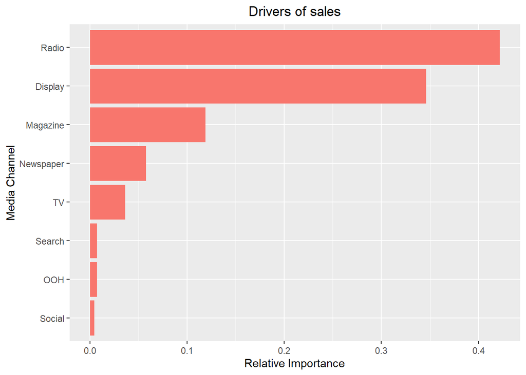

```r
relative_imp=relative_importance$car


contribution=data.frame(cbind(ChannelName=ChannelName,relative_imp=as.character(relative_imp)))%>%arrange(desc(relative_imp))
contribution$relative_imp=as.numeric(as.character(contribution$relative_imp))

ggplot(data = contribution, mapping = aes(x = reorder(ChannelName, round(contribution$relative_imp,3)), y = relative_imp,fill='steelblue'))+
  geom_bar(stat = 'identity')+
    xlab ("Media Channel")+
    ylab("Relative Importance") +
    ggtitle ("Drivers of sales")+theme(plot.title = element_text(hjust = 0.5))+guides(fill=F)+coord_flip()
```

```r
summary(modFit.4)
```

```
##
## Call:
## lm(formula = adjusted_sales ~ ., data = media_ad)
##
## Residuals:
##     Min      1Q  Median      3Q     Max
## -525.93  -59.04   27.34   80.98  470.71
##
## Coefficients:
##                  Estimate Std. Error t value Pr(>|t|)
## (Intercept)     1.546e+03  2.271e+02   6.806 2.61e-07 ***
## X_ad.Magazine   2.047e-03  1.565e-03   1.308 0.201913
## X_ad.Newspaper  3.521e-03  3.744e-03   0.941 0.355265
## X_ad.Radio      1.099e-02  2.924e-03   3.759 0.000835 ***
## X_ad.OOH       -5.569e-05  9.891e-04  -0.056 0.955511
## X_ad.TV        -1.403e-02  6.009e-03  -2.334 0.027256 *
## X_ad.Search     1.979e-04  2.363e-03   0.084 0.933868
## X_ad.Display   -1.192e-02  3.298e-03  -3.614 0.001216 **
## X_ad.Social     2.035e-03  1.742e-03   1.168 0.252954
## ---
## Signif. codes:  0 '***' 0.001 '**' 0.01 '*' 0.05 '.' 0.1 ' ' 1
##
## Residual standard error: 226.2 on 27 degrees of freedom
## Multiple R-squared:  0.6036, Adjusted R-squared:  0.4862
## F-statistic:  5.14 on 8 and 27 DF,  p-value: 0.0005854
```

```r
#what is the unit of sales?
# adjusted_sales?

sales_sum=sum(rawdata$Sales)
revenue_of_each_variable=relative_imp*sales_sum
spending_of_each_variable=colSums(X_ad)
ROAS=revenue_of_each_variable/spending_of_each_variable
ROAS
```

```
##  X_ad.Magazine X_ad.Newspaper     X_ad.Radio       X_ad.OOH        X_ad.TV
##   0.0245531524   0.0358428538   0.0390312961   0.0011123616   0.0143801338
##    X_ad.Search   X_ad.Display    X_ad.Social
##   0.0003828049   0.0311106194   0.0002703955
```

```r
print("====================")
```

```
## [1] "===================="
```

```r
sales_sum_1=sum(rawdata$Sales*(rawdata$Price1+rawdata$Price2+rawdata$Price3))
revenue_of_each_variable_1=relative_imp*sales_sum_1
ROAS_1=revenue_of_each_variable_1/spending_of_each_variable

ROAS_1
```

```
##  X_ad.Magazine X_ad.Newspaper     X_ad.Radio       X_ad.OOH        X_ad.TV
##     3.93732533     5.74773349     6.25902975     0.17837748     2.30598761
##    X_ad.Search   X_ad.Display    X_ad.Social
##     0.06138631     4.98887590     0.04336042
```

### 6 The following steps

- considering the prices;
- feature selection;
- model Selection;
- any other optimization;
- is the ROAS right?

#### 7 Reference

- https://www.listendata.com/2019/09/marketing-mix-modeling.html
- https://lonepatient.top/2018/06/10/time-series-nested-cross-validation.html#2-%E4%BB%BB%E6%84%8F%E9%80%89%E6%8B%A9%E6%B5%8B%E8%AF%95%E9%9B%86
- https://scikit-learn.org/stable/modules/cross_validation.html
- https://github.com/shatrunjai/MarketMixModelling/blob/master/FinalCode.R
- https://rpubs.com/nihil0/mmm01
- https://mpra.ub.uni-muenchen.de/7683/4/MPRA_paper_7683.pdf
- https://www.dataapplab.com/towardsdatascience-com-market-mix-modeling/
- https://www.latentview.com/marketing-mix-modeling/
- https://en.wikipedia.org/wiki/Advertising_adstock